# Overview of mutation burden and telomere length analysis

### Summary

1. Initial analysis of single nucleotide variant and indel burden
2. SNV and indel burden plots
3. Copy number and structural variant plots
4. Telomere length calculations and normality testing
5. Linear modelling

Open libraries

```r
suppressMessages(library(GenomicRanges))
suppressMessages(library(dplyr))
suppressMessages(library(tidyr))
suppressMessages(library(ggplot2))
suppressMessages(library(BiocGenerics))
suppressMessages(library(knitr))
suppressMessages(library(stringr))
suppressMessages(library(ggtree))
suppressMessages(library(ape))
suppressMessages(library(seqinr))
suppressMessages(library(data.table))
suppressMessages(library(phytools))
suppressMessages(library(Rsamtools))
suppressMessages(library(MASS))
suppressMessages(library(lme4))
suppressMessages(library(stats))
suppressMessages(library(RColorBrewer))
suppressMessages(library(ggpubr))
```

### 1) Initial analysis of single nucleotide variant and indel burden

The initial analysis of single nucleotide variant and indel burdens is illustrated using the KX001 (29 year male) dataset. The input files for this part of the analysis are available on Mendeley Data (data post removal of samples that failed QC): 1) mats_and_params_KX001_4_01 2) tree_KX001_4_01_standard_rho01.tree 3) annotated_mut_set_KX001_4_01__standard_rho01 4) KX001_4_sensitivity Note these input files are also available for all the individuals analysed.

##### Set working directory and define files and paths

```r
ID = "KX001" #Edit
Iteration = "KX001_4" #Edit
Run_ID = "KX001_4_01" #Edit
filtering_ID = "standard_rho01" #Edit
lim_snv = 1000 #Edit- used for ylim_snv on graphs of mutation burden
br_snv = c(200,400,600,800,1000)
lim_indel = 50 #Edit- used for ylim_snv on graphs of mutation burden
br_indel = c(10,20,30,40,50)
setwd = paste0("~/Documents/PhD/Sequencing_results/DNA_seq/",ID,"/",Iteration,"/subs/vaf_cut/") #Ensure this directory exists and copy mats_and_params file there
mats_and_param_file = paste0("~/Documents/PhD/Sequencing_results/DNA_seq/",ID,"/",Iteration,"/trees/vaf_cut/output/mats_and_params_", Run_ID)
tree_file_path = paste0("~/Documents/PhD/Sequencing_results/DNA_seq/",ID,"/",Iteration,"/trees/vaf_cut/output/tree_", Run_ID,"_",filtering_ID, ".tree")
file_annot = paste0("~/Documents/PhD/Sequencing_results/DNA_seq/",ID,"/",Iteration,"/trees/vaf_cut/output/annotated_mut_set_", Run_ID,"_",filtering_ID)
sensitivity_df = paste0("~/Documents/PhD/Sequencing_results/DNA_seq/",ID,"/",Iteration,"/trees/vaf_cut/output/",Iteration,"_sensitivity")
```

##### Load “local drive” functions

```r
source('~/Documents/Bioinformatics/CGP/Functions/foetal.filters.parallel.R')
```

```r
source('~/Documents/Bioinformatics/CGP/Functions/phytools_scripts.R')
source('~/Documents/Bioinformatics/CGP/Functions/plot_tree_examples.R')
source('~/Documents/Bioinformatics/CGP/Functions/plot_tree.R')
source('~/Documents/Bioinformatics/CGP/Functions/targeted_analysis_functions.R')
source('~/Documents/Bioinformatics/CGP/Functions/tree_functions_em.R')
source('~/Documents/Bioinformatics/CGP/Functions/tree_visualisation_em.R')
```

##### Load input files

```r
load(file_annot)
load(mats_and_param_file)
tree <- read.tree(tree_file_path)
sensitivity <- read.table(sensitivity_df, stringsAsFactors = F, header = T)
```

##### Save matrices of NV (mutant read number) and NR (total depth)

```r
write.csv(filtered_muts$COMB_mats.tree.build$NR, paste0("~/Documents/PhD/Sequencing_results/DNA_seq/",ID,"/",Iteration,"/subs/vaf_cut/mutation_burden/",Iteration,"_NR.csv"), row.names = T, quote=F)
write.csv(filtered_muts$COMB_mats.tree.build$NV, paste0("~/Documents/PhD/Sequencing_results/DNA_seq/",ID,"/",Iteration,"/subs/vaf_cut/mutation_burden/",Iteration,"_NV.csv"), row.names = T, quote=F)
```

##### Assessing SNV burden per colony

```r
SNVs_per_sample = colSums(filtered_muts$COMB_mats.tree.build$Genotype_bin[filtered_muts$COMB_mats.tree.build$mat$Mut_type == "SNV",] == 1)
mean(SNVs_per_sample); sd(SNVs_per_sample); range(SNVs_per_sample)
```

```
## [1] 427.4791
```

```
## [1] 65.34828
```

```
## [1] 228 632
```

```r
Mutation_burden <- as.data.frame(colSums(filtered_muts$COMB_mats.tree.build$Genotype_bin[filtered_muts$COMB_mats.tree.build$mat$Mut_type == "SNV",] == 1))
Mutation_burden$Mean_depth <- (colSums(filtered_muts$COMB_mats.tree.build$NR)/nrow(filtered_muts$COMB_mats.tree.build$NR))
colnames(Mutation_burden)[1] <- "Number_mutations"
Mutation_burden$Sample <- rownames(Mutation_burden)
Summary_snvs <- as.data.frame(cbind(Mutation_burden[,c(3,1,2)]))
```

##### Assessing Indel burden per colony

```r
INDELs_per_sample = colSums(filtered_muts$COMB_mats.tree.build$Genotype_bin[filtered_muts$COMB_mats.tree.build$mat$Mut_type == "INDEL",] == 1)
mean(INDELs_per_sample); sd(INDELs_per_sample); range(INDELs_per_sample)
```

```
## [1] 10.54545
```

```
## [1] 4.867938
```

```
## [1]  1 29
```

```r
Indel_burden <- as.data.frame(colSums(filtered_muts$COMB_mats.tree.build$Genotype_bin[filtered_muts$COMB_mats.tree.build$mat$Mut_type == "INDEL",] == 1))
Indel_burden$Mean_depth <- (colSums(filtered_muts$COMB_mats.tree.build$NR)/nrow(filtered_muts$COMB_mats.tree.build$NR))
colnames(Indel_burden)[1] <- "Number_indels"
Indel_burden$Sample <- rownames(Indel_burden)
Summary_indels <- as.data.frame(cbind(Indel_burden[,c(3,1,2)]))
```

##### Model to correct mutation burden for sequencing depth of coverage

Summary_snvs: data.frame with one row per sample and the following columns:  
Mean_depth: the average coverage per sample  
Number_mutations: the number of mutations per sample

```r
### Asymptotic model
# Sort data
sorted = sortedXyData(Summary_snvs$Mean_depth, Summary_snvs$Number_mutations)

# Run model
model.as = NLSstAsymptotic(sorted)
# Note: you will be alerted if the model does not converge (typically if data are not asymptotic or there is too little data)

# Look at results
model.as
```

```
##          b0          b1         lrc
## -475.427582 1048.466358   -1.869659
```

##### Create model function

```r
mymodel = function(x){
  b0 = model.as[1]
  b1 = model.as[2]
  lrc = model.as[3]
  b0 + b1*(1-exp(-exp(lrc) * x))
}
```

##### Plot model

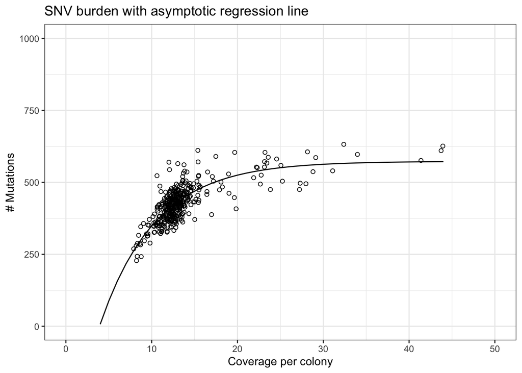

```r
myrange=1:round(max(Summary_snvs$Mean_depth))
asp = data.frame(x=myrange, y=unlist(lapply(myrange, FUN=mymodel)))
suppressWarnings(ggplot(Summary_snvs) +
  ylim(1,lim_snv)+
  xlim(0,50)+
  geom_point(aes(x=Mean_depth,y=Number_mutations), data=Summary_snvs, pch=21) +
  theme_bw() +
  scale_fill_brewer(type="qual", palette=3) +
  ylab("# Mutations") +
  xlab("Coverage per colony")+
  geom_line(aes(x=x, y=y), data=asp)+
  labs(title = "SNV burden with asymptotic regression line"))
```

##### Normalize mutation burden to a read depth of 30X

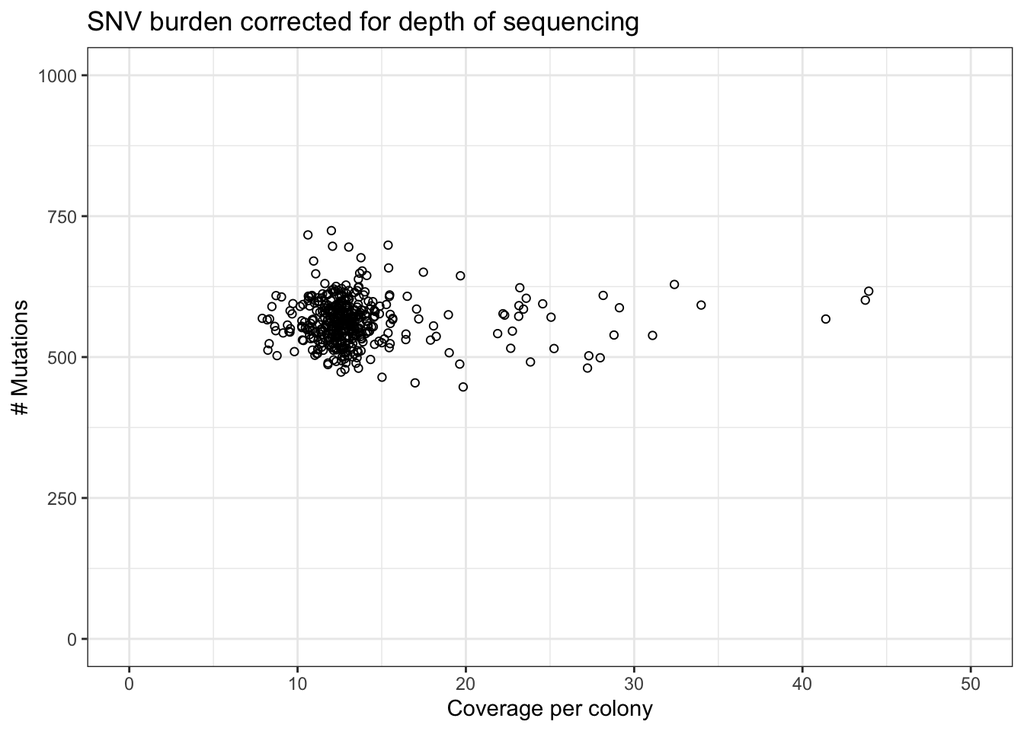

```r
new_Number_mutations = function(rd, Number_mutations){
  Number_mutations + ( mymodel(30) - mymodel(rd)) ## can change depth here
}
Summary_snvs$Number_mutations_adj_as = apply(Summary_snvs, MARGIN=1, FUN=function(X)  new_Number_mutations(rd=as.numeric(X[which(colnames(Summary_snvs)=="Mean_depth")]), Number_mutations=as.numeric(X[which(colnames(Summary_snvs)=="Number_mutations")]) ) )
ggplot(Summary_snvs) +
  ylim(0,lim_snv)+
  xlim(0,50)+
  theme_bw() +
  geom_point(aes(Mean_depth,Number_mutations_adj_as), pch=21) +
  ylab("# Mutations") +
  xlab("Coverage per colony")+
  labs(title ="SNV burden corrected for depth of sequencing")
```

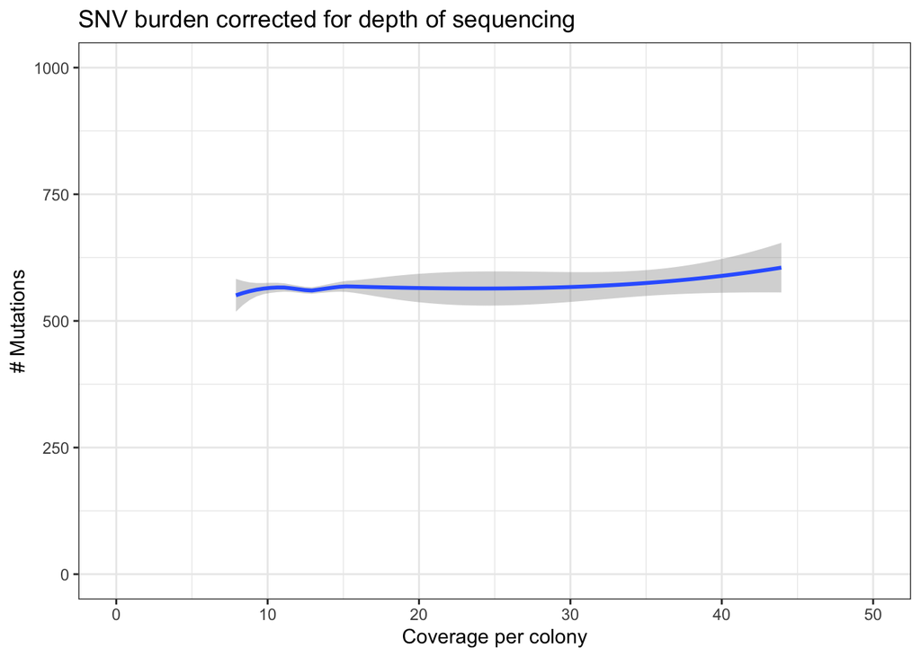

```r
ggplot(Summary_snvs) +
  ylim(0,lim_snv)+
  xlim(0,50)+
  theme_bw() +
  geom_smooth(aes(Mean_depth,Number_mutations_adj_as), pch=21) +
  ylab("# Mutations") +
  xlab("Coverage per colony")+
labs(title ="SNV burden corrected for depth of sequencing")
```

##### Save table of adjusted and unadjusted mutation burdens

```r
write.table(Summary_snvs, paste0("~/Documents/PhD/Sequencing_results/DNA_seq/",ID,"/",Iteration,"/subs/vaf_cut/mutation_burden/",Iteration,"_sub_dep_adj.txt"), sep="\t", col.names = T, row.names = F, quote=F)
```

##### Model to correct indel burden for sequencing depth of coverage

```r
### Asymptotic model
# Sort data
sorted = sortedXyData(Summary_indels$Mean_depth, Summary_indels$Number_indels)

# Run model
model.as = NLSstAsymptotic(sorted)
# Note: you will be alerted if the model does not converge (typically if data are not asymptotic or there is too little data)
# If data are more linear then a linear regression is reasonable.

# Look at results
model.as
```

```
##        b0        b1       lrc
## -21.30056  47.55293  -2.46786
```

##### Create model function

```r
mymodel = function(x){
  b0 = model.as[1]
  b1 = model.as[2]
  lrc = model.as[3]
  b0 + b1*(1-exp(-exp(lrc) * x))
}
```

##### Plot model

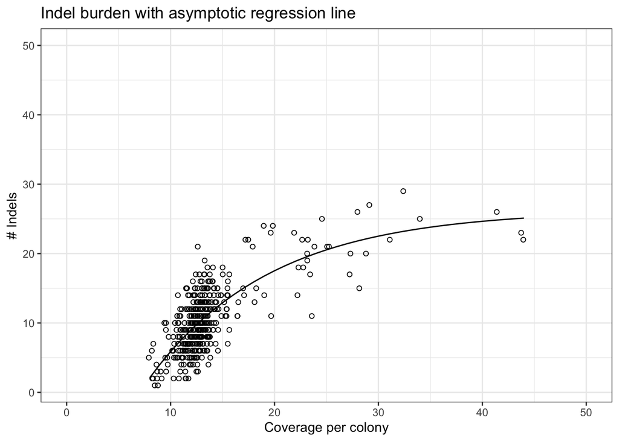

```r
myrange=1:round(max(Summary_indels$Mean_depth))
asp = data.frame(x=myrange, y=unlist(lapply(myrange, FUN=mymodel)))
suppressWarnings(ggplot(Summary_indels) +
  ylim(1,lim_indel)+
  xlim(0,50)+
  geom_point(aes(x=Mean_depth,y=Number_indels), data=Summary_indels, pch=21) +
  theme_bw() +
  scale_fill_brewer(type="qual", palette=3) +
  ylab("# Indels") +
  xlab("Coverage per colony")+
  geom_line(aes(x=x, y=y), data=asp)+
  labs(title ="Indel burden with asymptotic regression line"))
```

##### Normalize mutation burden to a read depth of 30X.

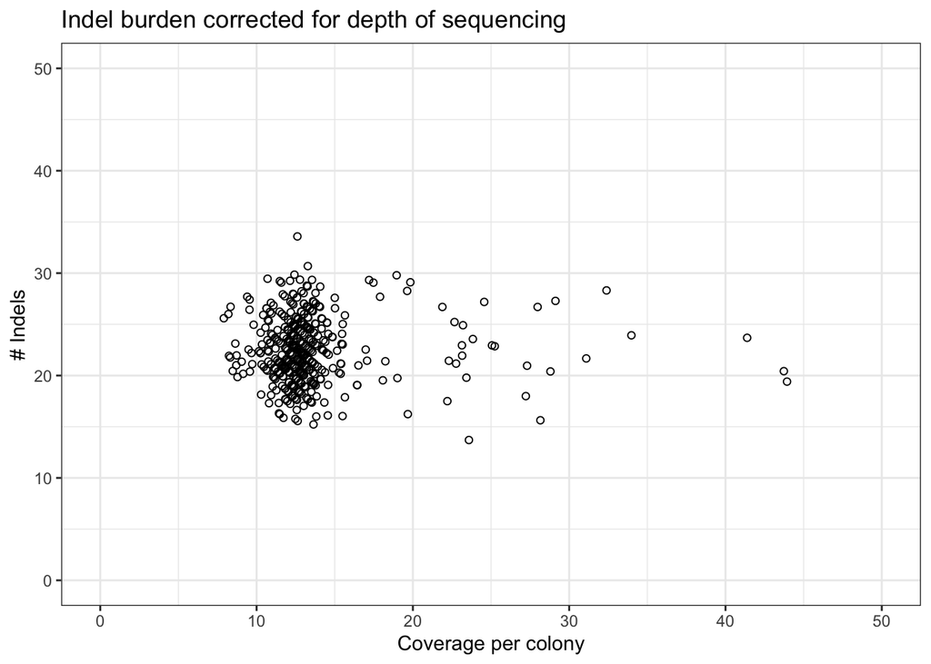

```r
new_Number_indels = function(rd, Number_indels){
  Number_indels + ( mymodel(30) - mymodel(rd)) ## can change depth here
}
Summary_indels$Number_indels_adj_as = apply(Summary_indels, MARGIN=1, FUN=function(X)  new_Number_indels(rd=as.numeric(X[which(colnames(Summary_indels)=="Mean_depth")]), Number_indels=as.numeric(X[which(colnames(Summary_indels)=="Number_indels")]) ) )
ggplot(Summary_indels) +
  ylim(0,lim_indel)+
  xlim(0,50)+
  theme_bw() +
  geom_point(aes(Mean_depth,Number_indels_adj_as), pch=21) +
  ylab("# Indels") +
  xlab("Coverage per colony")+
  labs(title ="Indel burden corrected for depth of sequencing")
```

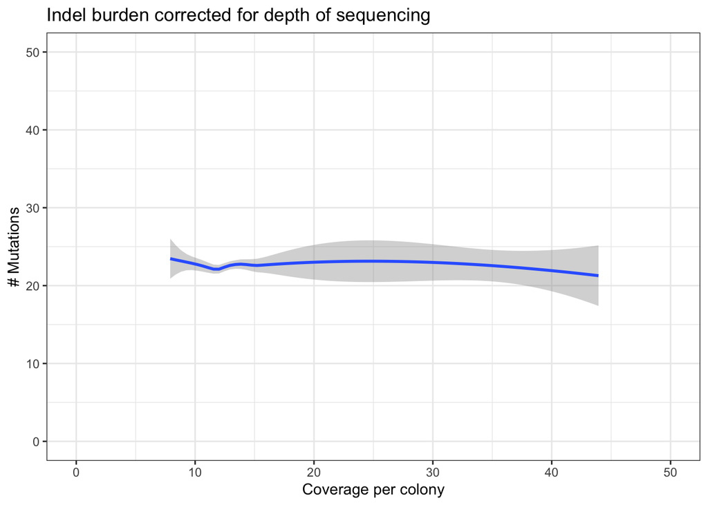

```r
ggplot(Summary_indels) +
  ylim(0,lim_indel)+
  xlim(0,50)+
  theme_bw() +
  geom_smooth(aes(Mean_depth,Number_indels_adj_as), pch=21) +
  ylab("# Mutations") +
  xlab("Coverage per colony")+
  labs(title ="Indel burden corrected for depth of sequencing")
```

##### Save table of unadjusted and adjusted indel burdens per sample

```r
write.table(Summary_indels, paste0("~/Documents/PhD/Sequencing_results/DNA_seq/",ID,"/",Iteration,"/subs/vaf_cut/mutation_burden/",Iteration,"_indel_dep_adj.txt"), sep="\t", col.names = T, row.names = F, quote=F)
```

##### Generate input for dnds

```r
dnds_input <- filtered_muts$COMB_mats.tree.build$mat[,2:5]
dnds_input$SampleID <- ID
colnames(dnds_input) <- c("Chr","Pos","Ref","Alt","SampleID")
dnds_input <- dnds_input[,c("SampleID","Chr","Pos","Ref","Alt")]
write.table(dnds_input, paste0("~/Documents/PhD/Sequencing_results/DNA_seq/",ID,"/",Iteration,"/subs/vaf_cut/dnds/",Iteration, "_dnds_all.txt"), sep="\t", col.names = T, row.names = F, quote=F)

create_dnds_files = function(mat, select_vector = NULL) {
  if(is.null(select_vector)) {dnds_file = mat[,2:5]} else {dnds_file = mat[select_vector,2:5]}
  dnds_file$SampleID <- ID
  colnames(dnds_file) <- c("Chr","Pos","Ref","Alt","SampleID")
  dnds_file <- dnds_file[,c("SampleID","Chr","Pos","Ref","Alt")]
  return(dnds_file)
}

shared_dnds_file = create_dnds_files(filtered_muts$COMB_mats.tree.build$mat, select_vector = filtered_muts$COMB_mats.tree.build$mat$mut_ref %in% rownames(filtered_muts$Genotype_shared_bin))

private_dnds_file = create_dnds_files(filtered_muts$COMB_mats.tree.build$mat, select_vector = !filtered_muts$COMB_mats.tree.build$mat$mut_ref %in% rownames(filtered_muts$Genotype_shared_bin))

write.table(shared_dnds_file, paste0("~/Documents/PhD/Sequencing_results/DNA_seq/",ID,"/",Iteration,"/subs/vaf_cut/dnds/",Iteration, "_dnds_shared.txt"), sep="\t", col.names = T, row.names = F, quote=F)

write.table(private_dnds_file, paste0("~/Documents/PhD/Sequencing_results/DNA_seq/",ID,"/",Iteration,"/subs/vaf_cut/dnds/",Iteration, "_dnds_private.txt"), sep="\t", col.names = T, row.names = F, quote=F)
```

##### Table of mutation calls per sample from tree

```r
new_genotype_mat <- filtered_muts$COMB_mats.tree.build$Genotype_bin
#Set all the genotypes to 0 as a baseline
new_genotype_mat[,] <- 0
details <- filtered_muts$COMB_mats.tree.build$mat

#Now go through each of the mutations in turn and replace the 0's with 1's
for(i in tree$edge[,2]) {
  node=i
  info=get_edge_info(tree,details,node)
  samples=info$samples
  muts=details$mut_ref[info$idx]
  new_genotype_mat[muts,samples] <- 1
}

write.csv(new_genotype_mat, paste0("~/Documents/PhD/Sequencing_results/DNA_seq/",ID,"/",Iteration,"/subs/vaf_cut/mutation_burden/",Iteration, "_mutation_calls_tree.csv"),row.names = T, quote=F)
```

##### Creating vcf files per sample

```r
new_genotype_mat <- cbind(filtered_muts$COMB_mats.tree.build$mat[,2:5],new_genotype_mat[,])

samples = colnames(new_genotype_mat[5:ncol(new_genotype_mat)])

for (sample in samples) {
#Write vcf files for VariantCaller analysis - separate out "All mutations", "Shared mutations", "Private mutations".
vcf_file = new_genotype_mat[(new_genotype_mat[,sample] >0),c(1:4)]
names(vcf_file) = c("#CHROM", "POS", "REF", "ALT")

#Add the required null columns
vcf_file$ID = vcf_file$QUAL = vcf_file$FILTER = vcf_file$INFO = "."

#Rearrange into correct order
vcf_file = vcf_file[,c(1,2,5,3,4,6,7,8)]

#Write files
write.table(vcf_file, sep = "\t", quote = FALSE, file = paste0("~/Documents/PhD/Sequencing_results/DNA_seq/",ID,"/",Iteration,"/subs/vaf_cut/hdp/",sample,"_mutations_all.vcf"), row.names = FALSE)
}
```

##### Generate input for signature analysis

```r
all_muts <- filtered_muts$COMB_mats.tree.build$mat[filtered_muts$COMB_mats.tree.build$mat$Mut_type == "SNV",]
all_muts <- all_muts[,c(2:5,7)]
all_muts$SampleID <- paste0(ID, "_", all_muts$node)
all_muts <- all_muts[,c(1:4,6)]
colnames(all_muts) <- c("Chr","Pos","Ref","Alt","SampleID")
```

##### Generate mutation spectrum of all samples pooled

```r
genomeFile = "/Users/em16/Documents/Bioinformatics/CGP/Reference_genomes/hs37d5.fa"

subs_only = all_muts
nrow(subs_only)
```

```
## [1] 160216
```

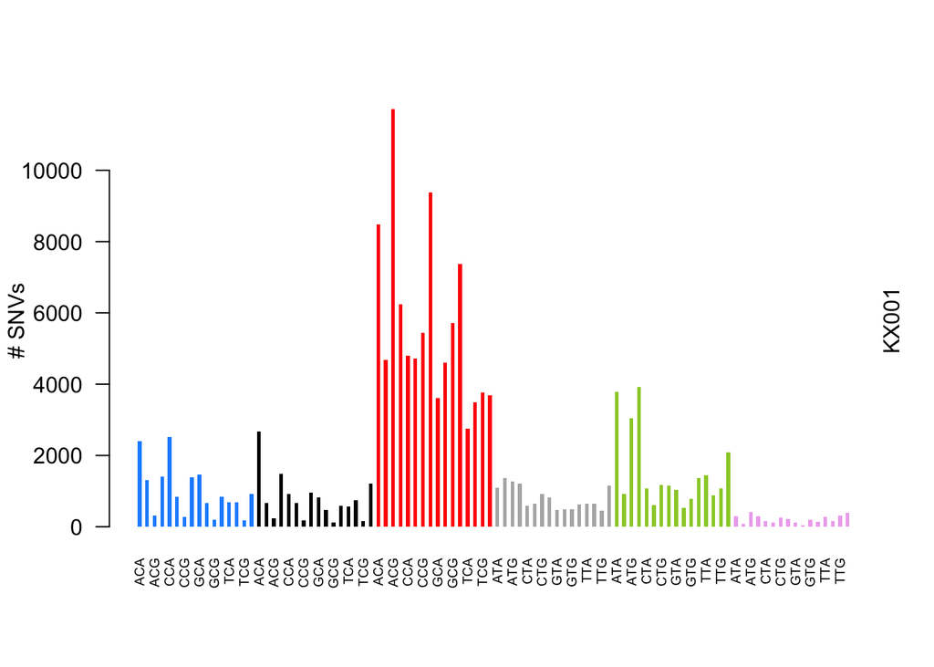

```r
  colnames(subs_only) = c("chr", "pos", "ref", "mut")
  subs_only = subs_only[(subs_only$ref %in% c("A","C","G","T")) & (subs_only$mut %in% c("A","C","G","T")) & subs_only$chr %in% c(1:22,"X","Y"),]
  subs_only$trinuc_ref = as.vector(scanFa(genomeFile, GRanges(subs_only$chr, IRanges(subs_only$pos-1, subs_only$pos+1))))

  # 2. Annotating the mutation from the pyrimidine base
  ntcomp = c(T="A",G="C",C="G",A="T")
  subs_only$sub = paste(subs_only$ref,subs_only$mut,sep=">")
  subs_only$trinuc_ref_py = subs_only$trinuc_ref
  for (j in 1:nrow(subs_only)) {
    if (subs_only$ref[j] %in% c("A","G")) { # Purine base
      subs_only$sub[j] = paste(ntcomp[subs_only$ref[j]],ntcomp[subs_only$mut[j]],sep=">")
      subs_only$trinuc_ref_py[j] = paste(ntcomp[rev(strsplit(subs_only$trinuc_ref[j],split="")[[1]])],collapse="")
    }
  }

 # 3. Counting subs
  freqs = table(paste(subs_only$sub,paste(substr(subs_only$trinuc_ref_py,1,1),substr(subs_only$trinuc_ref_py,3,3),sep="-"),sep=","))
  sub_vec = c("C>A","C>G","C>T","T>A","T>C","T>G")
  ctx_vec = paste(rep(c("A","C","G","T"),each=4),rep(c("A","C","G","T"),times=4),sep="-")
  full_vec = paste(rep(sub_vec,each=16),rep(ctx_vec,times=6),sep=",")
  freqs_full = freqs[full_vec]
  freqs_full[is.na(freqs_full)] = 0
  names(freqs_full) = full_vec

  xstr = paste(substr(full_vec,5,5), substr(full_vec,1,1), substr(full_vec,7,7), sep="")

  colvec = rep(c("dodgerblue","black","red","grey70","olivedrab3","plum2"),each=16)
  y = freqs_full
  maxy = max(y)

  h=barplot(y, las=2, col=colvec, border=NA, ylim_snv=c(0,maxy*1.5), space=1, cex.names=0.6, names.arg=xstr, ylab="# SNVs")
  mtext(side=4, text= ID)
  for (j in 1:length(sub_vec)) {
    xpos = h[c((j-1)*16+1,j*16)]
    rect(xpos[1]-0.5, maxy*1.2, xpos[2]+0.5, maxy*1.3, border=NA, col=colvec[j*16])
    text(x=mean(xpos), y=maxy*1.3, pos=3, label=sub_vec[j])
  }
```

### 2) SNV and indel burden plots

This analysis is performed using a matrix of mutation burdens, indel burdens and telomere lengths per sample - available in mutation_telomere_analysis/input/Summary_cut.csv. The .csv file containing information on colony efficiency is available in mutation_telomere_analysis/input/Colony_efficiency_cut.csv)

##### Load colony efficiency file

```r
col_efficiency <- read.csv("~/Documents/PhD/Lab_work/Colony_efficiency/Colony_efficiency_cut.csv", stringsAsFactors = F)
```

##### Load matrix of mutation burdens, indel burdens and telomere lengths per sample

```r
summ_cut <- read.csv("~/Documents/PhD/Sequencing_results/DNA_seq/XX_summary/telomere_mutation/data/Summary_cut.csv",  stringsAsFactors = F)
```

```r
summ_cut$donor_id <- factor(summ_cut$donor_id, levels = c("CB001", "CB002", "KX001", "KX002","SX001","AX001", "KX007","KX008","KX004","KX003"))
col_efficiency$donor_id <- factor(col_efficiency$donor_id, levels = c("CB001", "CB002", "KX001", "KX002","SX001","AX001", "KX007","KX008","KX004","KX003"))
```

##### Plot of colony forming efficiency

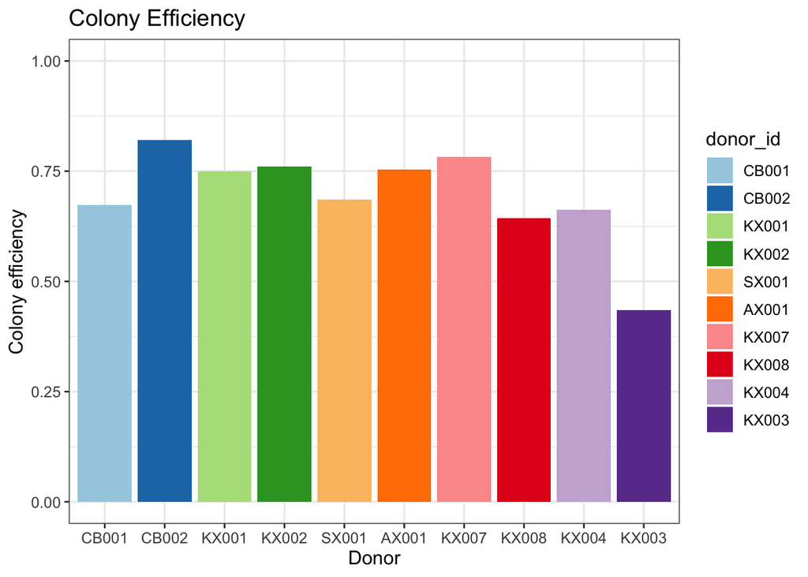

```r
ggplot(col_efficiency)+
  theme_bw()+
  scale_fill_manual(values = brewer.pal(10,"Paired")[c(1:4,7,8,5,6,9,10)])+
  labs(y="Colony efficiency", x="Donor")+
  theme(text=element_text(size=12))+
  ylim(0,1.0)+
  geom_col(aes(group = donor_id, y= efficiency, x = donor_id, fill = donor_id), width = 0.9)+
  labs(title = "Colony Efficiency")
```

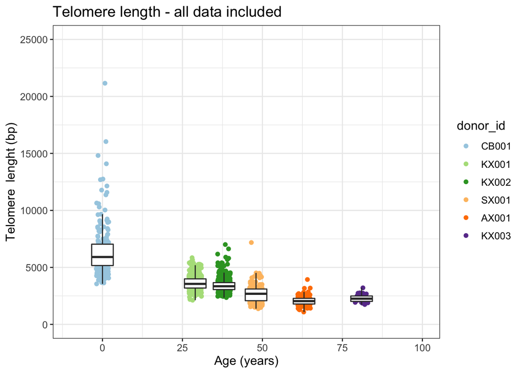

```r
ggplot(summ_cut[summ_cut$platform == "hiseq" & summ_cut$cell_type == "HSC",])+
  theme_bw()+
  labs(x="Age (years)", y="Telomere  lenght (bp)")+
  xlim(-10,100)+
  ylim(0,25000)+
  theme(text=element_text(size=12))+
  guides(fill="none")+
  scale_color_manual(values = brewer.pal(10,"Paired")[c(1,3,4,7,8,10)])+
  geom_jitter(aes(group = donor_id, x = age, y =tel_length, col = donor_id), width = 2)+
geom_boxplot(aes(group = donor_id, x = age, y =tel_length), outlier.alpha = 0 )+
  labs(title = "Telomere length - all data included")
```

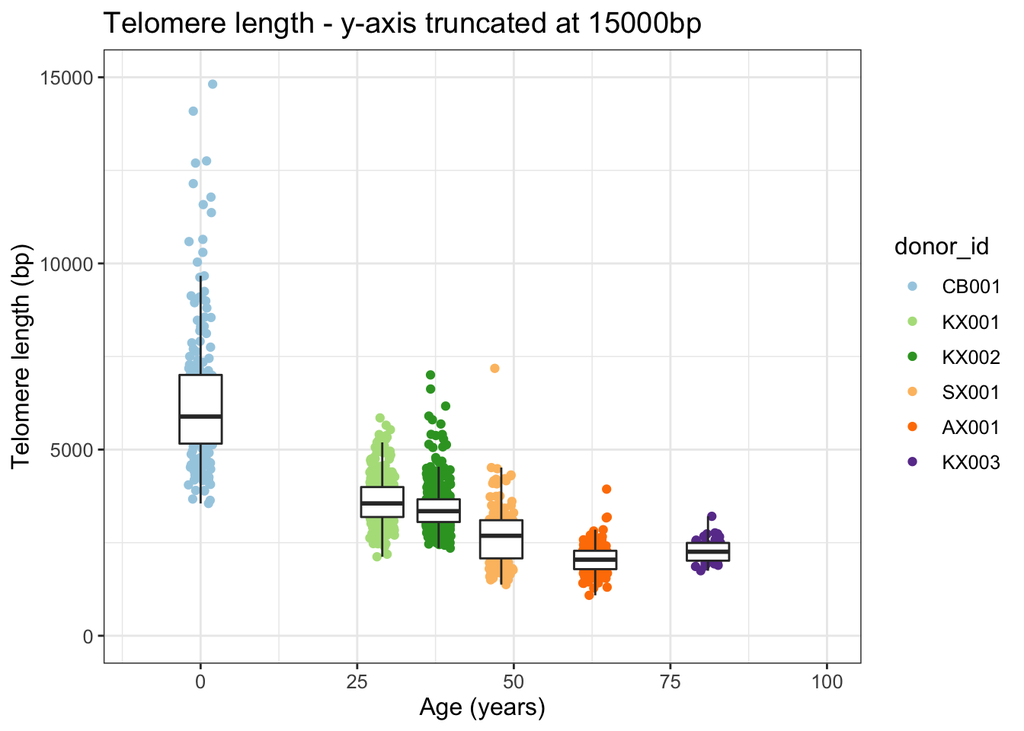

```r
ggplot(summ_cut[summ_cut$platform == "hiseq" & summ_cut$cell_type == "HSC",])+
  theme_bw()+
  labs(x="Age (years)", y="Telomere length (bp)")+
  xlim(-10,100)+
  ylim(0,15000)+
  theme(text=element_text(size=12))+
  guides(fill="none")+
  scale_color_manual(values = brewer.pal(10,"Paired")[c(1,3,4,7,8,10)])+
  geom_jitter(aes(group = donor_id, x = age, y =tel_length, col = donor_id), width = 2)+
  geom_boxplot(aes(group = donor_id, x = age, y =tel_length), outlier.alpha = 0 )+
  labs(title = "Telomere length - y-axis truncated at 15000bp")
```

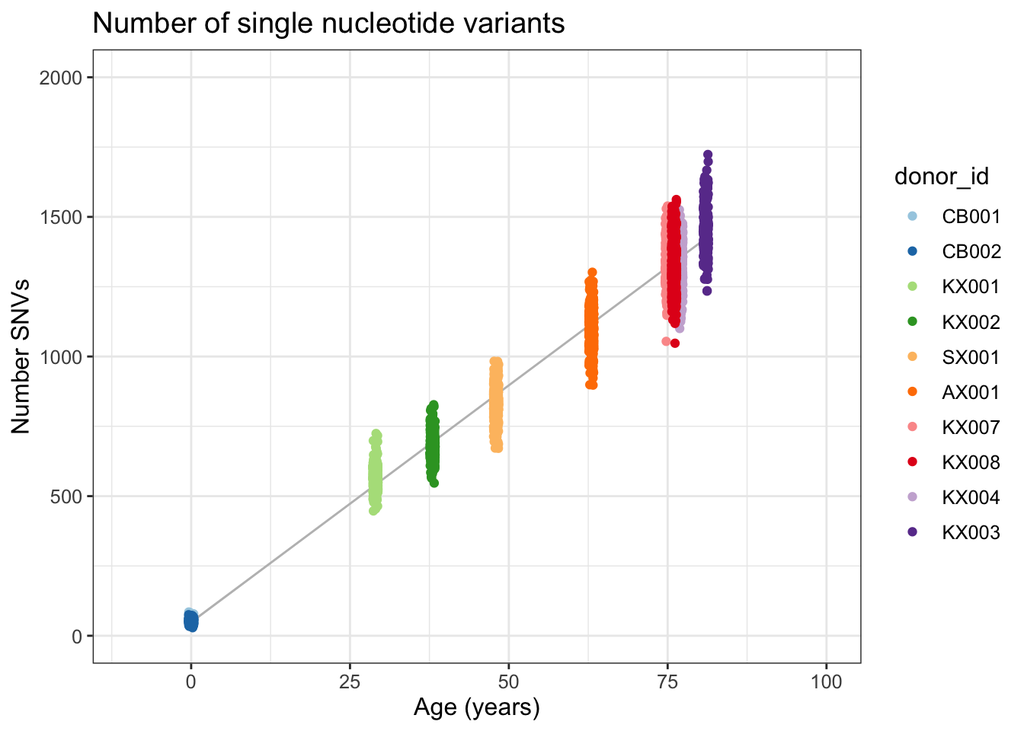

```r
ggplot(summ_cut[summ_cut$cell_type == "HSC",])+
  theme_bw()+
  labs(x="Age (years)", y="Number SNVs")+
  xlim(-10,100)+
  ylim(0,2000)+
  theme(text=element_text(size=12))+
  guides(fill="none")+
  scale_color_manual(values = brewer.pal(10,"Paired")[c(1:4,7,8,5,6,9,10)])+
  geom_smooth(data = (summ_cut[summ_cut$cell_type == "HSC",]), method = "lm",aes(x = age, y =sub_adj), size = 0.5, colour = "grey", se = T)+
  geom_jitter(aes(group = donor_id, x = age, y =sub_adj, col = donor_id))+
  labs(title ="Number of single nucleotide variants")
```

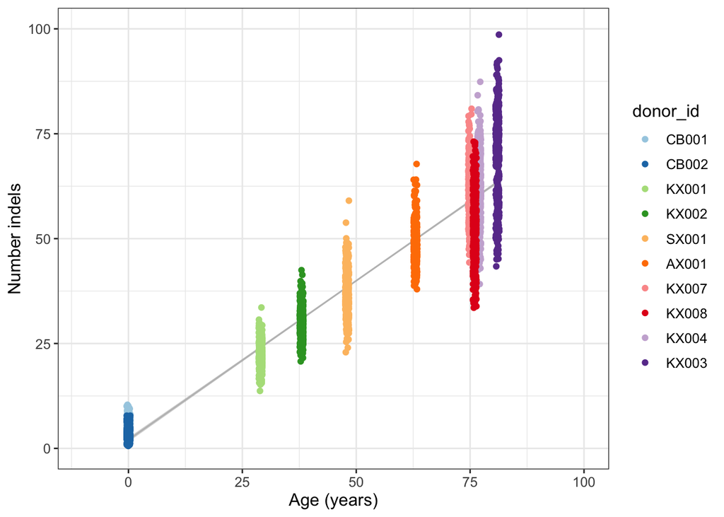

```r
ggplot(summ_cut[summ_cut$cell_type == "HSC",])+
  theme_bw()+
  labs(x="Age (years)", y="Number indels")+
  xlim(-10,100)+
  ylim(0,100)+
  theme(text=element_text(size=12))+
  geom_smooth(data = (summ_cut[summ_cut$cell_type == "HSC",]), method = "lm",aes(x = age, y =indel_adj), size = 0.5, colour = "grey", se = T)+
  guides(fill="none")+
  scale_color_manual(values = brewer.pal(10,"Paired")[c(1:4,7,8,5,6,9,10)])+
  geom_jitter(aes(group = donor_id, x = age, y =indel_adj, col = donor_id))+
  labs("Number of indels")
```

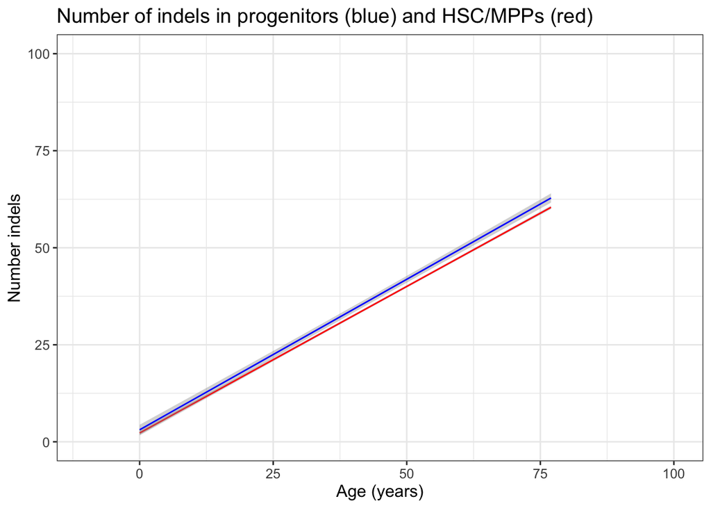

```r
ggplot(subset(summ_cut, summ_cut$donor_id %in% c("CB002","SX001","AX001","KX004")))+
  theme_bw()+
  labs(x="Age (years)", y="Number indels")+
  xlim(-10,100)+
  ylim(0,100)+
  theme(text=element_text(size=12))+
geom_smooth(data = (subset(summ_cut, summ_cut$donor_id %in% c("CB002","SX001","AX001","KX004") & summ_cut$cell_type == "HSC")), method = "lm",aes(x = age, y =indel_adj), size = 0.5, colour = "red", se = T)+
  geom_smooth(data = (subset(summ_cut, summ_cut$donor_id %in% c("CB002","SX001","AX001","KX004") & summ_cut$cell_type == "Progenitor")), method = "lm",aes(x = age, y =indel_adj), size = 0.5, colour = "blue", se = T)+
  labs(title = "Number of indels in progenitors (blue) and HSC/MPPs (red)")
```

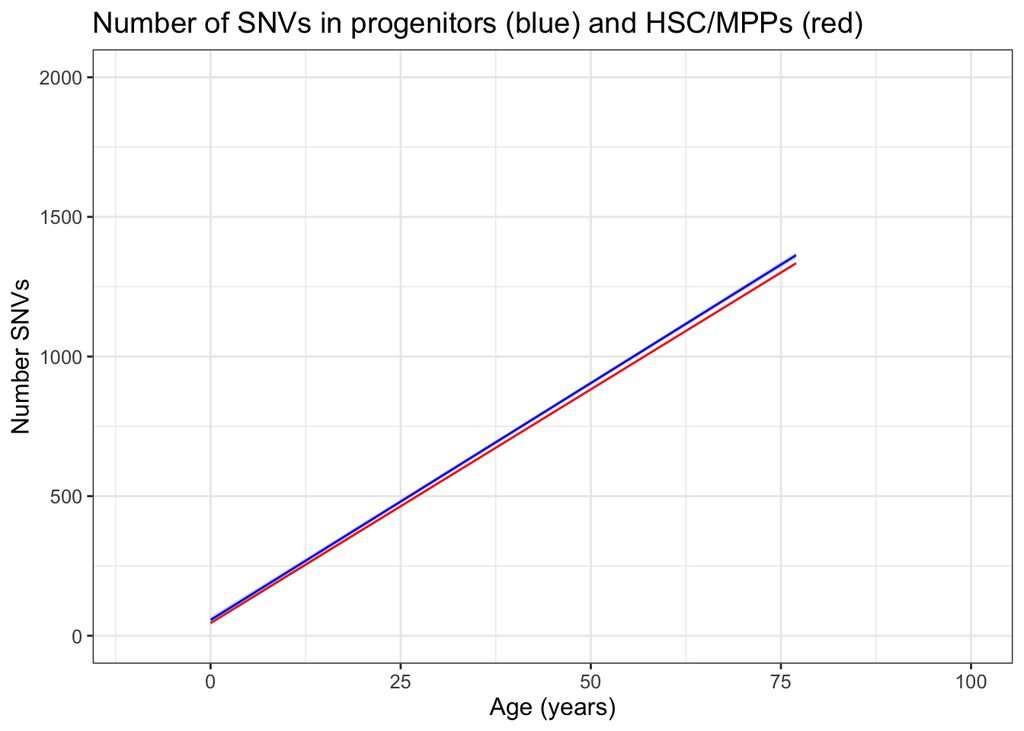

```r
ggplot(subset(summ_cut, summ_cut$donor_id %in% c("CB002","SX001","AX001","KX004")))+
  theme_bw()+
  labs(x="Age (years)", y="Number SNVs")+
  xlim(-10,100)+
  ylim(0,2000)+
  theme(text=element_text(size=12))+
  geom_smooth(data = (subset(summ_cut, summ_cut$donor_id %in% c("CB002","SX001","AX001","KX004") & summ_cut$cell_type == "HSC")), method = "lm",aes(x = age, y =sub_adj), size = 0.5, colour = "red", se = T)+
  geom_smooth(data = (subset(summ_cut, summ_cut$donor_id %in% c("CB002","SX001","AX001","KX004") & summ_cut$cell_type == "Progenitor")), method = "lm",aes(x = age, y =sub_adj), size = 0.5, colour = "blue", se = T)+
  labs(title = "Number of SNVs in progenitors (blue) and HSC/MPPs (red)")
```

### 3) Copy number and structural variant plots

This analysis is performed using data files available in the mutation_telomere_analysis/input/ folder.

##### Load matrices of copy number / structural variant type per sample number for each donor

```r
SV_summ <- read.csv("~/Documents/PhD/Sequencing_results/DNA_seq/XX_summary/telomere_mutation/data/SV_summ.csv", stringsAsFactors = F, row.names = 1)
CN_summ <- read.csv("~/Documents/PhD/Sequencing_results/DNA_seq/XX_summary/telomere_mutation/data/CN_summ.csv", stringsAsFactors = F, row.names = 1)
```

##### Cut CN / SV matrices to rows of interest

```r
SV_summ <- as.matrix(SV_summ[6:9,],)
CN_summ <- as.matrix(CN_summ[6:9,])
```

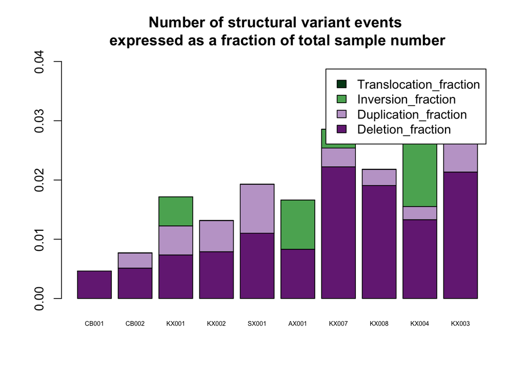

```r
barplot(SV_summ, beside = FALSE, names.arg = c("CB001","CB002","KX001","KX002","SX001","AX001","KX007","KX008","KX004","KX003"), col = brewer.pal(10,"PRGn")[c(2,4,8,10)], ylim = c(0,0.04), cex.names = 0.5, legend.text = T,main = "Number of structural variant events \nexpressed as a fraction of total sample number")
```

### 4) Telomere length calculations and normality testing

These analyses are performed using the Summary_cut.csv file loaded earlier as the summ_cut object.

##### Calculation mean sequencing depth

```r
mean(summ_cut$mean_depth)
```

```
## [1] 14.13358
```

##### Calculation mean telomere length in cord blood

```r
mean_tel_CB001 <- mean(summ_cut$tel_length[summ_cut$donor_id == "CB001"])
mean_tel_CB001
```

```
## [1] 6946.516
```

##### Calculation telomere length loss per year in adult life HSC compartment

```r
KX001_meantel <- mean(summ_cut$tel_length[summ_cut$donor_id == "KX001"])
AX001_meantel <- mean(summ_cut$tel_length[summ_cut$donor_id == "AX001" & summ_cut$platform == "hiseq"])
(KX001_meantel - AX001_meantel)/34
```

```
## [1] 45.82385
```

##### Tests of normality of telomere length distributions for each donor

```r
shapiro.test(summ_cut$tel_length[summ_cut$donor_id == "CB001" & summ_cut$cell_type == "HSC" & summ_cut$platform == "hiseq"])
```

```
##
##  Shapiro-Wilk normality test
##
## data:  summ_cut$tel_length[summ_cut$donor_id == "CB001" & summ_cut$cell_type == "HSC" & summ_cut$platform == "hiseq"]
## W = 0.79028, p-value = 1.058e-15
```

```r
shapiro.test(summ_cut$tel_length[summ_cut$donor_id == "KX001" & summ_cut$cell_type == "HSC" & summ_cut$platform == "hiseq"])
```

```
##
##  Shapiro-Wilk normality test
##
## data:  summ_cut$tel_length[summ_cut$donor_id == "KX001" & summ_cut$cell_type == "HSC" & summ_cut$platform == "hiseq"]
## W = 0.97028, p-value = 2.297e-07
```

```r
shapiro.test(summ_cut$tel_length[summ_cut$donor_id == "KX002" & summ_cut$cell_type == "HSC" & summ_cut$platform == "hiseq"])
```

```
##
##  Shapiro-Wilk normality test
##
## data:  summ_cut$tel_length[summ_cut$donor_id == "KX002" & summ_cut$cell_type == "HSC" & summ_cut$platform == "hiseq"]
## W = 0.86813, p-value < 2.2e-16
```

```r
shapiro.test(summ_cut$tel_length[summ_cut$donor_id == "SX001" & summ_cut$cell_type == "HSC" & summ_cut$platform == "hiseq"])
```

```
##
##  Shapiro-Wilk normality test
##
## data:  summ_cut$tel_length[summ_cut$donor_id == "SX001" & summ_cut$cell_type == "HSC" & summ_cut$platform == "hiseq"]
## W = 0.91815, p-value = 1.847e-08
```

```r
shapiro.test(summ_cut$tel_length[summ_cut$donor_id == "AX001" & summ_cut$cell_type == "HSC" & summ_cut$platform == "hiseq"])
```

```
##
##  Shapiro-Wilk normality test
##
## data:  summ_cut$tel_length[summ_cut$donor_id == "AX001" & summ_cut$cell_type == "HSC" & summ_cut$platform == "hiseq"]
## W = 0.95725, p-value = 3.08e-05
```

```r
shapiro.test(summ_cut$tel_length[summ_cut$donor_id == "KX003" & summ_cut$cell_type == "HSC" & summ_cut$platform == "hiseq"])
```

```
##
##  Shapiro-Wilk normality test
##
## data:  summ_cut$tel_length[summ_cut$donor_id == "KX003" & summ_cut$cell_type == "HSC" & summ_cut$platform == "hiseq"]
## W = 0.9627, p-value = 0.1953
```

##### Q-Q plots showing the correlation between telomere lengths and the normal distribution for each donor

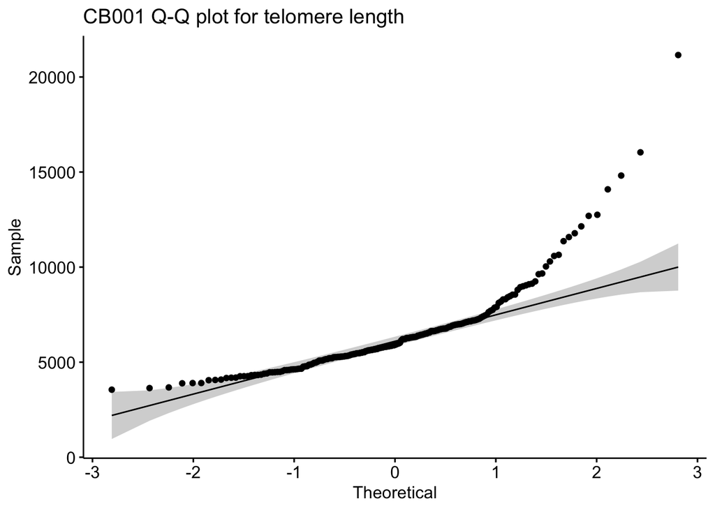

```r
ggqqplot(summ_cut$tel_length[summ_cut$donor_id == "CB001" & summ_cut$cell_type == "HSC" & summ_cut$platform == "hiseq"], main = "CB001 Q-Q plot for telomere length")
```

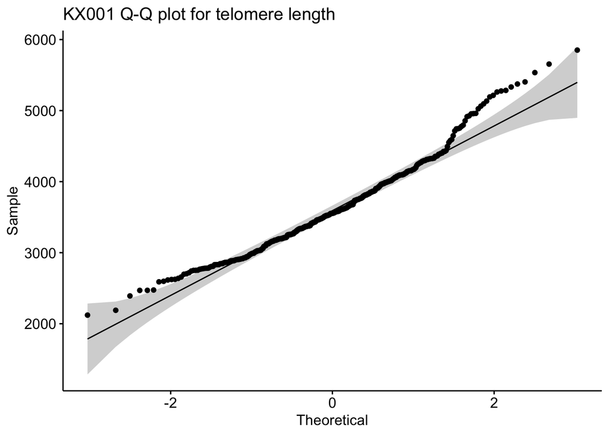

```r
ggqqplot(summ_cut$tel_length[summ_cut$donor_id == "KX001" & summ_cut$cell_type == "HSC" & summ_cut$platform == "hiseq"], main = "KX001 Q-Q plot for telomere length")
```

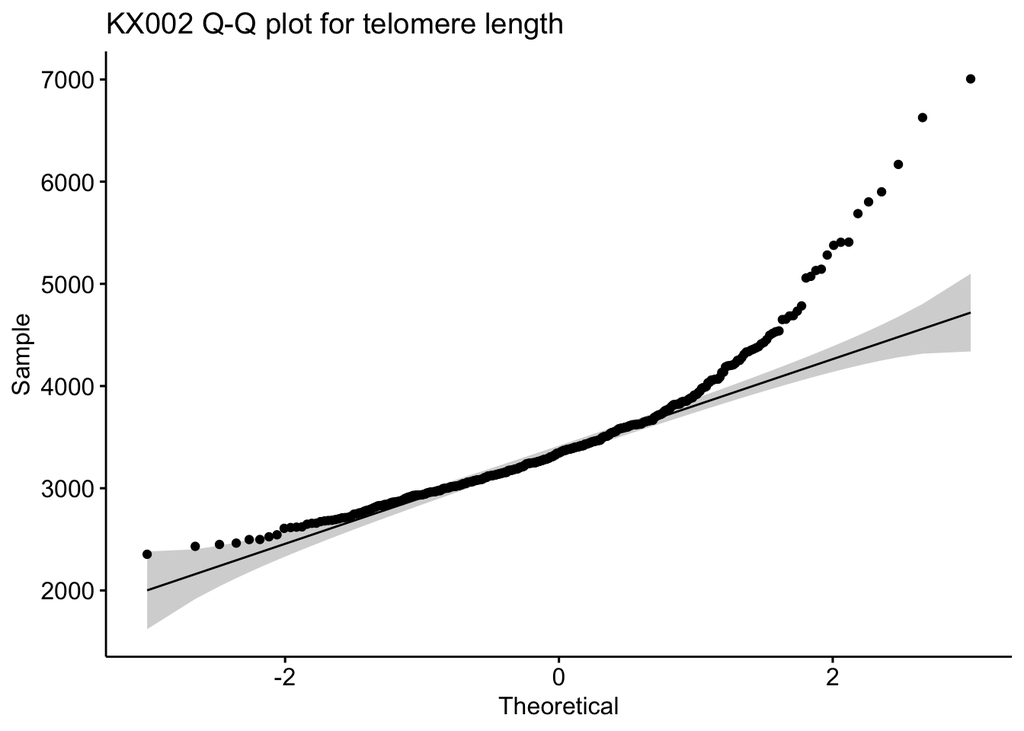

```r
ggqqplot(summ_cut$tel_length[summ_cut$donor_id == "KX002" & summ_cut$cell_type == "HSC" & summ_cut$platform == "hiseq"], main = "KX002 Q-Q plot for telomere length")
```

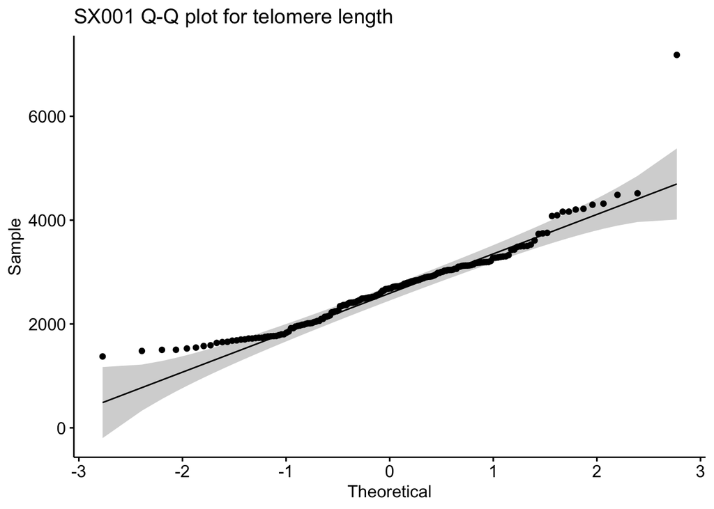

```r
ggqqplot(summ_cut$tel_length[summ_cut$donor_id == "SX001" & summ_cut$cell_type == "HSC" & summ_cut$platform == "hiseq"], main = "SX001 Q-Q plot for telomere length")
```

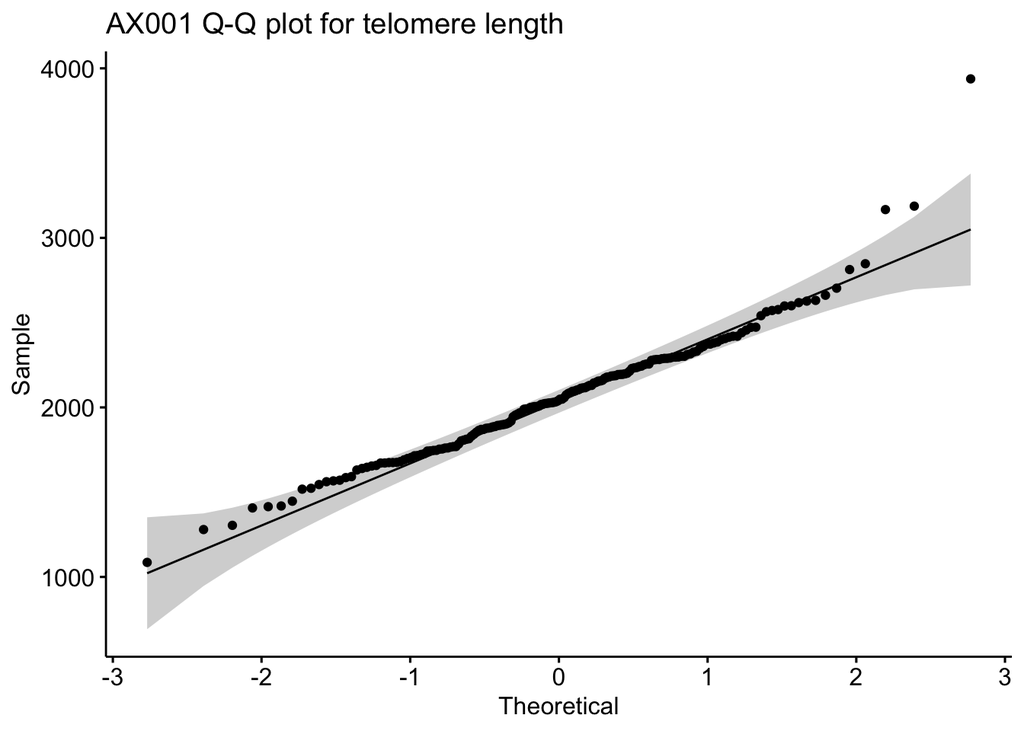

```r
ggqqplot(summ_cut$tel_length[summ_cut$donor_id == "AX001" & summ_cut$cell_type == "HSC" & summ_cut$platform == "hiseq"], main = "AX001 Q-Q plot for telomere length")
```

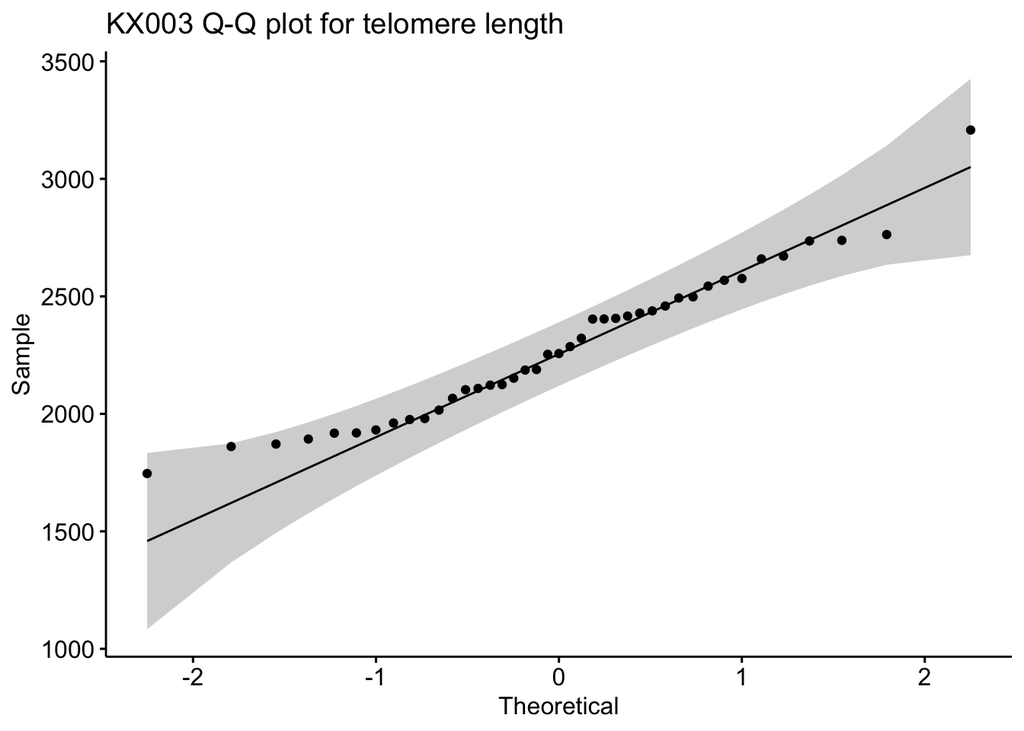

```r
ggqqplot(summ_cut$tel_length[summ_cut$donor_id == "KX003" & summ_cut$cell_type == "HSC" & summ_cut$platform == "hiseq"], main = "KX003 Q-Q plot for telomere length")
```

##### Density plot to visualise distribution of telomere lengths

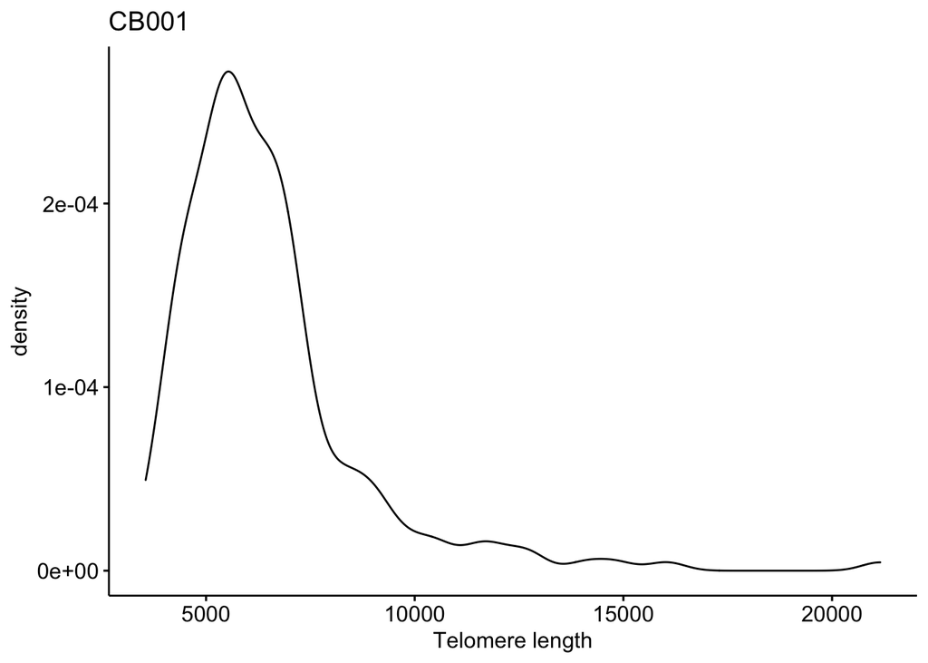

```r
ggdensity(summ_cut$tel_length[summ_cut$donor_id == "CB001" & summ_cut$cell_type == "HSC" & summ_cut$platform == "hiseq"], main = "CB001", xlab = "Telomere length")
```

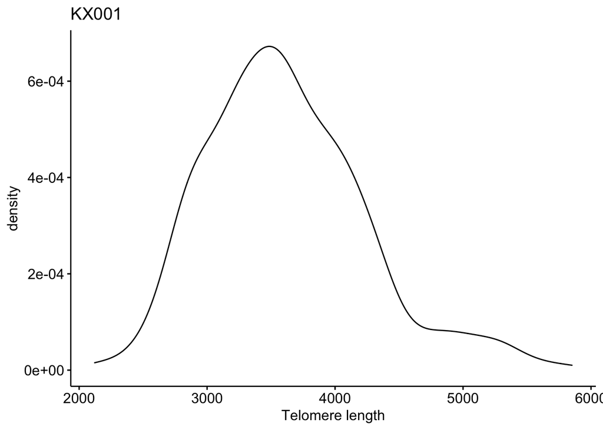

```r
ggdensity(summ_cut$tel_length[summ_cut$donor_id == "KX001" & summ_cut$cell_type == "HSC" & summ_cut$platform == "hiseq"], main = "KX001", xlab = "Telomere length")
```

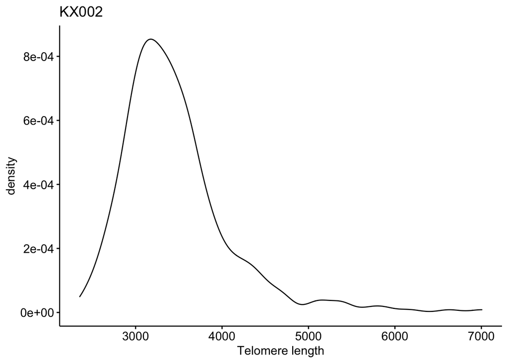

```r
ggdensity(summ_cut$tel_length[summ_cut$donor_id == "KX002" & summ_cut$cell_type == "HSC" & summ_cut$platform == "hiseq"], main = "KX002", xlab = "Telomere length")
```

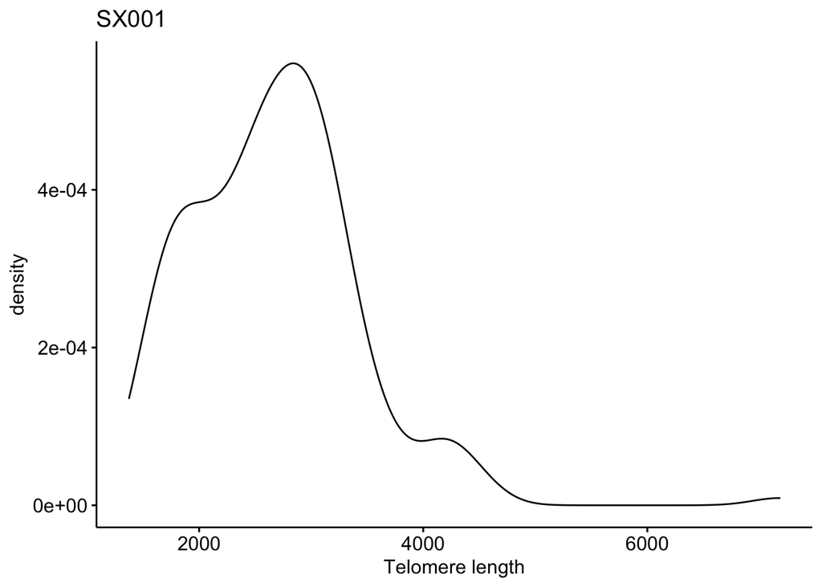

```r
ggdensity(summ_cut$tel_length[summ_cut$donor_id == "SX001" & summ_cut$cell_type == "HSC" & summ_cut$platform == "hiseq"], main = "SX001", xlab = "Telomere length")
```

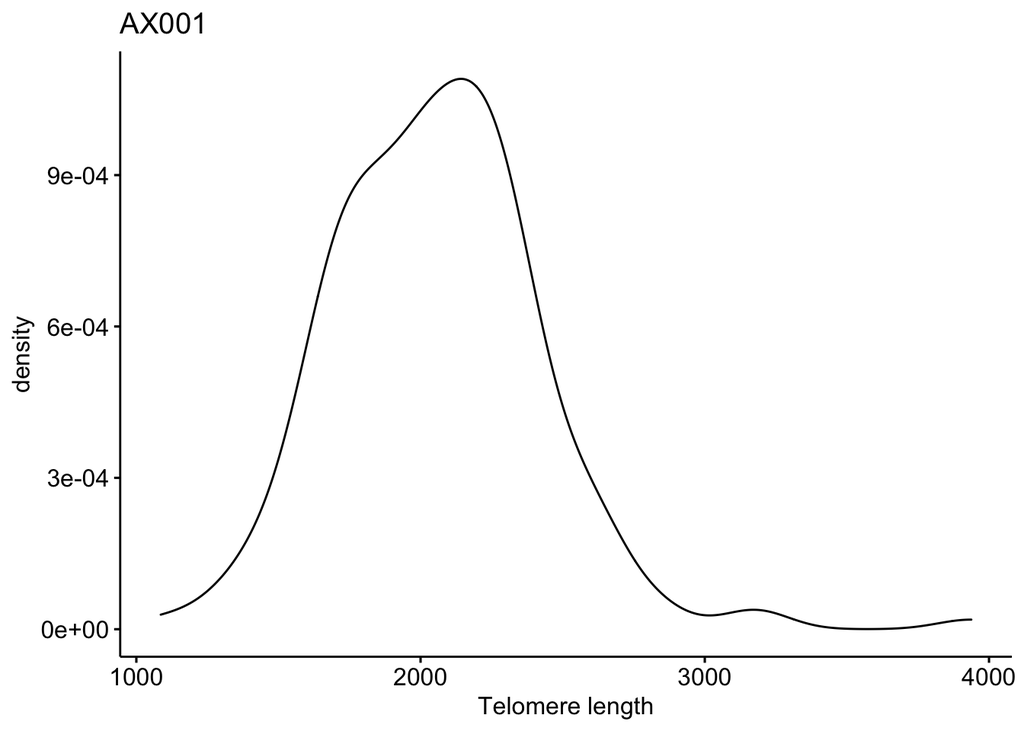

```r
ggdensity(summ_cut$tel_length[summ_cut$donor_id == "AX001" & summ_cut$cell_type == "HSC" & summ_cut$platform == "hiseq"], main = "AX001", xlab = "Telomere length")
```

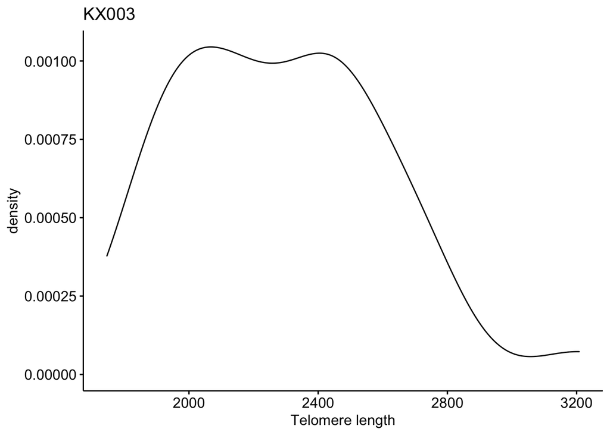

```r
ggdensity(summ_cut$tel_length[summ_cut$donor_id == "KX003" & summ_cut$cell_type == "HSC" & summ_cut$platform == "hiseq"], main = "KX003", xlab = "Telomere length")
```

### 5) Linear models

These analyses are performed using the Summary_cut.csv file loaded earlier as the summ_cut object.

##### Linear model to assess the effect of age on the accumulation of SNVs in HSC/MPPs

```r
age.mut <- lmer(sub_adj ~ age + (age | donor_id), data = summ_cut[summ_cut$cell_type == "HSC",], REML = F)
age.mut
```

```
## Linear mixed model fit by maximum likelihood  ['lmerMod']
## Formula: sub_adj ~ age + (age | donor_id)
##    Data: summ_cut[summ_cut$cell_type == "HSC", ]
##       AIC       BIC    logLik  deviance  df.resid
##  37678.95  37715.70 -18833.48  37666.95      3368
## Random effects:
##  Groups   Name        Std.Dev. Corr
##  donor_id (Intercept)  0.6415
##           age          0.3974  0.88
##  Residual             63.9678
## Number of obs: 3374, groups:  donor_id, 10
## Fixed Effects:
## (Intercept)          age
##       54.56        16.83
## optimizer (nloptwrap) convergence code: 0 (OK) ; 0 optimizer warnings; 1 lme4 warnings
```

```r
summary(age.mut)
```

```
## Linear mixed model fit by maximum likelihood  ['lmerMod']
## Formula: sub_adj ~ age + (age | donor_id)
##    Data: summ_cut[summ_cut$cell_type == "HSC", ]
##
##      AIC      BIC   logLik deviance df.resid
##  37679.0  37715.7 -18833.5  37667.0     3368
##
## Scaled residuals:
##     Min      1Q  Median      3Q     Max
## -4.4624 -0.5091 -0.0147  0.4903  4.1829
##
## Random effects:
##  Groups   Name        Variance  Std.Dev. Corr
##  donor_id (Intercept)    0.4115  0.6415
##           age            0.1579  0.3974  0.88
##  Residual             4091.8787 63.9678
## Number of obs: 3374, groups:  donor_id, 10
##
## Fixed effects:
##             Estimate Std. Error t value
## (Intercept)  54.5628     2.8373   19.23
## age          16.8323     0.1551  108.54
##
## Correlation of Fixed Effects:
##     (Intr)
## age -0.336
## optimizer (nloptwrap) convergence code: 0 (OK)
## Model failed to converge with max|grad| = 1.07699 (tol = 0.002, component 1)
```

##### Linear model to assess the effect of age on the accumulation of indels in HSC/MPPs

```r
age.indel <- lmer(indel_adj ~ age + (age | donor_id), data = summ_cut[summ_cut$cell_type == "HSC",], REML = F)
age.indel
```

```
## Linear mixed model fit by maximum likelihood  ['lmerMod']
## Formula: indel_adj ~ age + (age | donor_id)
##    Data: summ_cut[summ_cut$cell_type == "HSC", ]
##       AIC       BIC    logLik  deviance  df.resid
##  22110.33  22147.08 -11049.17  22098.33      3368
## Random effects:
##  Groups   Name        Std.Dev. Corr
##  donor_id (Intercept) 1.4271
##           age         0.0798   -0.98
##  Residual             6.3588
## Number of obs: 3374, groups:  donor_id, 10
## Fixed Effects:
## (Intercept)          age
##      3.2883       0.7071
## optimizer (nloptwrap) convergence code: 0 (OK) ; 0 optimizer warnings; 2 lme4 warnings
```

```r
summary(age.indel)
```

```
## Linear mixed model fit by maximum likelihood  ['lmerMod']
## Formula: indel_adj ~ age + (age | donor_id)
##    Data: summ_cut[summ_cut$cell_type == "HSC", ]
##
##      AIC      BIC   logLik deviance df.resid
##  22110.3  22147.1 -11049.2  22098.3     3368
##
## Scaled residuals:
##     Min      1Q  Median      3Q     Max
## -4.1395 -0.4755 -0.0186  0.5354  4.5450
##
## Random effects:
##  Groups   Name        Variance  Std.Dev. Corr
##  donor_id (Intercept)  2.036731 1.4271
##           age          0.006367 0.0798   -0.98
##  Residual             40.434389 6.3588
## Number of obs: 3374, groups:  donor_id, 10
##
## Fixed effects:
##             Estimate Std. Error t value
## (Intercept)  3.28828    0.93376   3.522
## age          0.70707    0.02757  25.650
##
## Correlation of Fixed Effects:
##     (Intr)
## age -0.756
## optimizer (nloptwrap) convergence code: 0 (OK)
## unable to evaluate scaled gradient
## Model failed to converge: degenerate  Hessian with 2 negative eigenvalues
```

##### Linear model to assess effect of age on telomere length including only the ‘young adult’ individuals

```r
age.tel <- lmer(tel_length ~ age + (age | donor_id), data = subset(summ_cut, summ_cut$platform == "hiseq" & !summ_cut$donor_id %in% c("CB001", "KX003") & summ_cut$cell_type == "HSC"), REML = F)
age.tel
```

```
## Linear mixed model fit by maximum likelihood  ['lmerMod']
## Formula: tel_length ~ age + (age | donor_id)
##    Data:
## subset(summ_cut, summ_cut$platform == "hiseq" & !summ_cut$donor_id %in%
##     c("CB001", "KX003") & summ_cut$cell_type == "HSC")
##       AIC       BIC    logLik  deviance  df.resid
## 17992.773 18023.027 -8990.387 17980.773      1138
## Random effects:
##  Groups   Name        Std.Dev. Corr
##  donor_id (Intercept) 598.742
##           age           9.665  -1.00
##  Residual             623.289
## Number of obs: 1144, groups:  donor_id, 4
## Fixed Effects:
## (Intercept)          age
##     5068.64       -47.82
## optimizer (nloptwrap) convergence code: 0 (OK) ; 0 optimizer warnings; 1 lme4 warnings
```

```r
summary(age.tel)
```

```
## Linear mixed model fit by maximum likelihood  ['lmerMod']
## Formula: tel_length ~ age + (age | donor_id)
##    Data:
## subset(summ_cut, summ_cut$platform == "hiseq" & !summ_cut$donor_id %in%
##     c("CB001", "KX003") & summ_cut$cell_type == "HSC")
##
##      AIC      BIC   logLik deviance df.resid
##  17992.8  18023.0  -8990.4  17980.8     1138
##
## Scaled residuals:
##     Min      1Q  Median      3Q     Max
## -2.4018 -0.6403 -0.0954  0.4822  7.2163
##
## Random effects:
##  Groups   Name        Variance  Std.Dev. Corr
##  donor_id (Intercept) 358492.54 598.742
##           age             93.42   9.665  -1.00
##  Residual             388489.63 623.289
## Number of obs: 1144, groups:  donor_id, 4
##
## Fixed effects:
##             Estimate Std. Error t value
## (Intercept) 5068.644    353.658  14.332
## age          -47.824      5.845  -8.182
##
## Correlation of Fixed Effects:
##     (Intr)
## age -0.992
## optimizer (nloptwrap) convergence code: 0 (OK)
## boundary (singular) fit: see ?isSingular
```

##### Linear model to assess the effect of age and cell type on the accumulation of SNVs

```r
age.cell.type <- lmer(sub_adj ~ age + cell_type + (age | donor_id) + (cell_type | donor_id), data = subset(summ_cut, summ_cut$donor_id %in% c("CB002","SX001","AX001","KX004")), REML = F)
age.cell.type
```

```
## Linear mixed model fit by maximum likelihood  ['lmerMod']
## Formula: sub_adj ~ age + cell_type + (age | donor_id) + (cell_type | donor_id)
##    Data: subset(summ_cut, summ_cut$donor_id %in% c("CB002", "SX001", "AX001",
##     "KX004"))
##       AIC       BIC    logLik  deviance  df.resid
## 17394.194 17447.744 -8687.097 17374.194      1554
## Random effects:
##  Groups     Name                Std.Dev. Corr
##  donor_id   (Intercept)         16.4177
##             age                  0.2034  -1.00
##  donor_id.1 (Intercept)         10.4668
##             cell_typeProgenitor 39.9909  -0.93
##  Residual                       62.1517
## Number of obs: 1564, groups:  donor_id, 4
## Fixed Effects:
##         (Intercept)                  age  cell_typeProgenitor
##               35.55                16.93                32.39
## optimizer (nloptwrap) convergence code: 0 (OK) ; 0 optimizer warnings; 1 lme4 warnings
```

```r
summary(age.cell.type)
```

```
## Linear mixed model fit by maximum likelihood  ['lmerMod']
## Formula: sub_adj ~ age + cell_type + (age | donor_id) + (cell_type | donor_id)
##    Data: subset(summ_cut, summ_cut$donor_id %in% c("CB002", "SX001", "AX001",
##     "KX004"))
##
##      AIC      BIC   logLik deviance df.resid
##  17394.2  17447.7  -8687.1  17374.2     1554
##
## Scaled residuals:
##     Min      1Q  Median      3Q     Max
## -3.9144 -0.4066  0.0111  0.5050  3.2502
##
## Random effects:
##  Groups     Name                Variance  Std.Dev. Corr
##  donor_id   (Intercept)         2.695e+02 16.4177
##             age                 4.136e-02  0.2034  -1.00
##  donor_id.1 (Intercept)         1.096e+02 10.4668
##             cell_typeProgenitor 1.599e+03 39.9909  -0.93
##  Residual                       3.863e+03 62.1517
## Number of obs: 1564, groups:  donor_id, 4
##
## Fixed effects:
##                     Estimate Std. Error t value
## (Intercept)          35.5452    14.5463   2.444
## age                  16.9312     0.2059  82.227
## cell_typeProgenitor  32.3889    21.0481   1.539
##
## Correlation of Fixed Effects:
##             (Intr) age
## age         -0.911
## cll_typPrgn -0.287 -0.046
## optimizer (nloptwrap) convergence code: 0 (OK)
## boundary (singular) fit: see ?isSingular
```

##### Linear model to assess the effect of age and cell type on the accumulation of indels

```r
age.cell.type.indel <- lmer(indel_adj ~ age + cell_type + (age | donor_id) + (cell_type | donor_id), data = subset(summ_cut, summ_cut$donor_id %in% c("CB002","SX001","AX001","KX004")), REML = F)
age.cell.type.indel
```

```
## Linear mixed model fit by maximum likelihood  ['lmerMod']
## Formula: indel_adj ~ age + cell_type + (age | donor_id) + (cell_type |
##     donor_id)
##    Data: subset(summ_cut, summ_cut$donor_id %in% c("CB002", "SX001", "AX001",
##     "KX004"))
##       AIC       BIC    logLik  deviance  df.resid
##  9913.536  9967.086 -4946.768  9893.536      1554
## Random effects:
##  Groups     Name                Std.Dev. Corr
##  donor_id   (Intercept)         0.007185
##             age                 0.026109 -0.99
##  donor_id.1 (Intercept)         0.042272
##             cell_typeProgenitor 0.270893 0.85
##  Residual                       5.700129
## Number of obs: 1564, groups:  donor_id, 4
## Fixed Effects:
##         (Intercept)                  age  cell_typeProgenitor
##              3.0520               0.7343               0.6391
## optimizer (nloptwrap) convergence code: 0 (OK) ; 0 optimizer warnings; 2 lme4 warnings
```

```r
summary(age.cell.type.indel)
```

```
## Linear mixed model fit by maximum likelihood  ['lmerMod']
## Formula: indel_adj ~ age + cell_type + (age | donor_id) + (cell_type |
##     donor_id)
##    Data: subset(summ_cut, summ_cut$donor_id %in% c("CB002", "SX001", "AX001",
##     "KX004"))
##
##      AIC      BIC   logLik deviance df.resid
##   9913.5   9967.1  -4946.8   9893.5     1554
##
## Scaled residuals:
##     Min      1Q  Median      3Q     Max
## -4.0498 -0.4778 -0.0354  0.4971  4.4072
##
## Random effects:
##  Groups     Name                Variance  Std.Dev. Corr
##  donor_id   (Intercept)         5.162e-05 0.007185
##             age                 6.817e-04 0.026109 -0.99
##  donor_id.1 (Intercept)         1.787e-03 0.042272
##             cell_typeProgenitor 7.338e-02 0.270893 0.85
##  Residual                       3.249e+01 5.700129
## Number of obs: 1564, groups:  donor_id, 4
##
## Fixed effects:
##                     Estimate Std. Error t value
## (Intercept)          3.05199    0.31648   9.644
## age                  0.73428    0.01612  45.555
## cell_typeProgenitor  0.63913    0.46481   1.375
##
## Correlation of Fixed Effects:
##             (Intr) age
## age         -0.316
## cll_typPrgn -0.278  0.059
## optimizer (nloptwrap) convergence code: 0 (OK)
## unable to evaluate scaled gradient
## Model failed to converge: degenerate  Hessian with 1 negative eigenvalues
```